# STAT 400 HW 1

Justin Wininger

Due: Friday, Jan 31, 2025 by 11:59 PM

## Problem

This problem is inspired by the Beyond Multiple Linear Regression (BMLR) book Guided Exercise 1 [Gender discrimination in bank salaries](https://bookdown.org/roback/bookdown-BeyondMLR/ch-MLRreview.html#guided-exercises). The data for this problem, banksalary.csv, may be found on the [textbook’s Github page](https://github.com/proback/BeyondMLR). A description of the variables in the dataset may be found in the textbook problem statement.

## Front Matter - Clean Environment, Load Libraries, User Defined Functions

## HW Tasks

```r
bankSalary <- read.csv(file = "https://raw.githubusercontent.com/proback/BeyondMLR/master/data/banksalary.csv", header=T)
```

1. Identify observational units, the response variable, and explanatory variables. NOTE: Observational units are the units from which the response is measured. This is different than the units of measurement.

The observational units are each worker at the bank. The response variable is their beginning salary, and the explanatory variables are their sex, months since starting, age, years of education, and months of prior work experience.

2. The mean starting salary of male workers ($5957) was 16% higher than the mean starting salary of female workers ($5139). Confirm these mean salaries. Is this enough evidence to conclude gender discrimination exists? If not, what further evidence would you need?

```r
bankSalary <- bankSalary %>% mutate(
  sexIND=ifelse(sex == 'MALE', 1, 0)
)

bankSalary$bsal <- as.integer(bankSalary$bsal)

bankSalary %>% group_by(sex) %>% summarize(mean = round(mean(bsal), digits=0))
```

```
## # A tibble: 2 × 2
##   sex     mean
##   <chr>  <dbl>
## 1 FEMALE  5139
## 2 MALE    5957
```

The mean salaries are correct, but this is not enough information to conclude that gender discrimination exists. To make that conclusion, I would need the p-value from a t-test.

3. How would you expect age, experience, and education to be related to starting salary? Generate appropriate exploratory plots that show the relationship between the response and each of these explanatory variables broken down (faceted) by sex. Are the relationships as you expected?

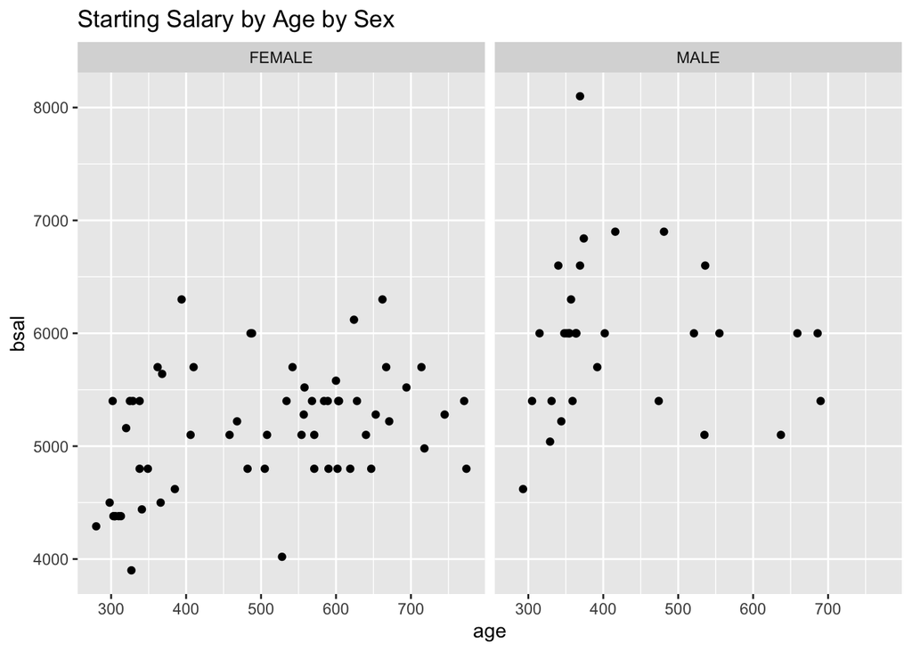

```r
bankSalary %>% ggplot(mapping = aes(x = age, y = bsal))+
  geom_point()+
  facet_grid(.~sex)+
  labs(title = "Starting Salary by Age by Sex")
```

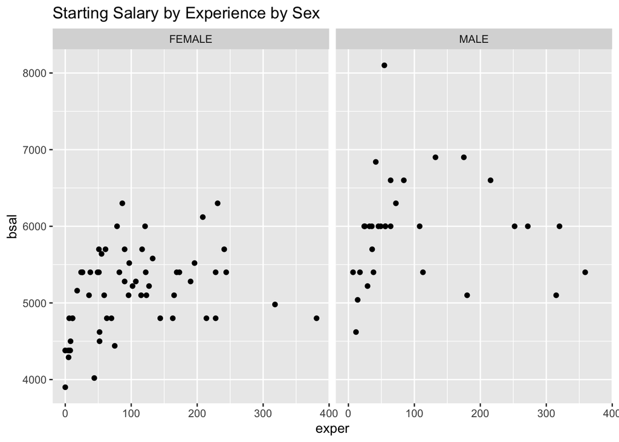

```r
bankSalary %>% ggplot(mapping = aes(x = exper, y = bsal))+
  geom_point()+
  facet_grid(.~sex)+
  labs(title = "Starting Salary by Experience by Sex")
```

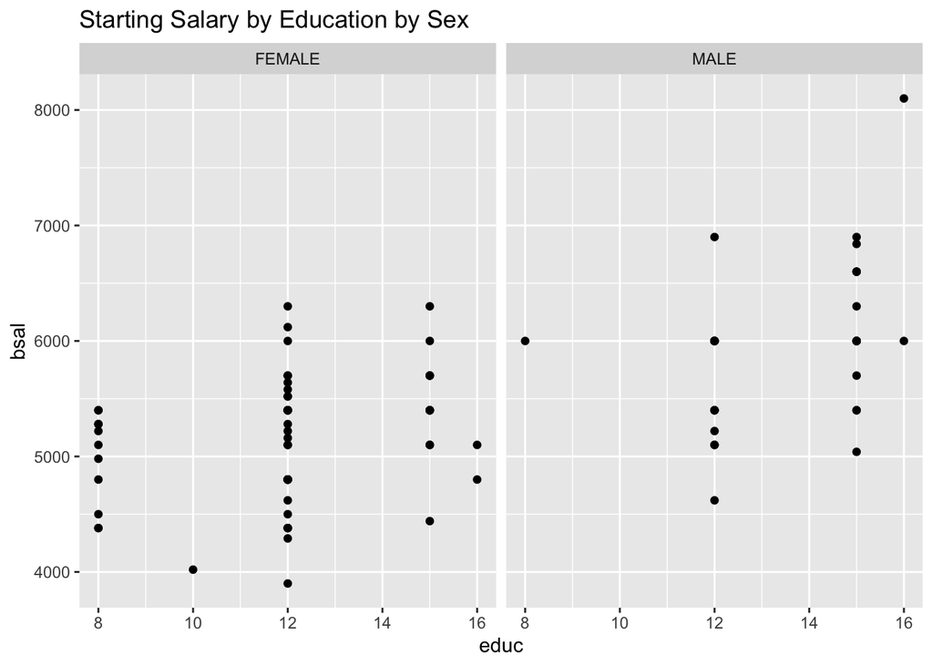

```r
bankSalary %>% ggplot(mapping = aes(x = educ, y = bsal))+
  geom_point()+
  facet_grid(.~sex)+
  labs(title = "Starting Salary by Education by Sex")
```

4. Fit a simple linear regression model with starting salary as the response and experience as the sole explanatory variable (Model 1). Interpret the intercept and slope of this model; also interpret the R-squared value. Is there a statistically significant relationship between experience and starting salary?

```r
model1 <- lm(bsal~exper, data = bankSalary)
summary(model1)
```

```
##
## Call:
## lm(formula = bsal ~ exper, data = bankSalary)
##
## Residuals:
##      Min       1Q   Median       3Q      Max
## -1389.02  -503.33   -36.03   383.14  2740.08
##
## Coefficients:
##              Estimate Std. Error t value Pr(>|t|)
## (Intercept) 5289.0217   109.2984  48.391   <2e-16 ***
## exper          1.3009     0.8064   1.613     0.11
## ---
## Signif. codes:  0 '***' 0.001 '**' 0.01 '*' 0.05 '.' 0.1 ' ' 1
##
## Residual standard error: 703.5 on 91 degrees of freedom
## Multiple R-squared:  0.0278, Adjusted R-squared:  0.01712
## F-statistic: 2.602 on 1 and 91 DF,  p-value: 0.1102
```

The intercept of 5289.02 is the theoretical starting salary for an employee with no experience. The slope of 1.3009 is how much a one unit change in experience changes starting salary. In this case, one month more of experience should result in a starting salary that is $1.30 higher. The R-squared value is 0.0278, meaning that 2.78% of variance in starting salary can be explained by experience. There is not a statistically significant relationship between experience and starting salary at the 0.05 level because the p-value is 0.11.

5. Find a 95% confidence interval for the impact of experience on starting salary. Is it surprising that the interval contains 0? Explain.

```r
confint(model1, level = 0.95)
```

```
##                    2.5 %      97.5 %
## (Intercept) 5071.9137511 5506.129600
## exper         -0.3009575    2.902845
```

It is not surprising that the interval contains 0 because the relationship is not statistically significant, so 0 would make sense.

6. Consider a model (Model 2) for starting salary that includes 4 explanatory variables (senior, educ, exper, and age). Do you believe the multiple regression assumptions are satisfied when using Model 2? Be sure to include appropriate plots/diagnostics.

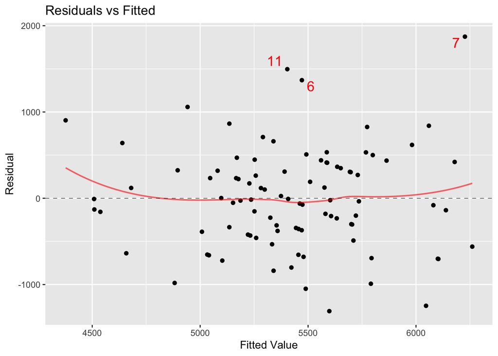

```r
model2 <- lm(bsal~senior+educ+exper+age, data = bankSalary)
mplot(model2, which=1)
```

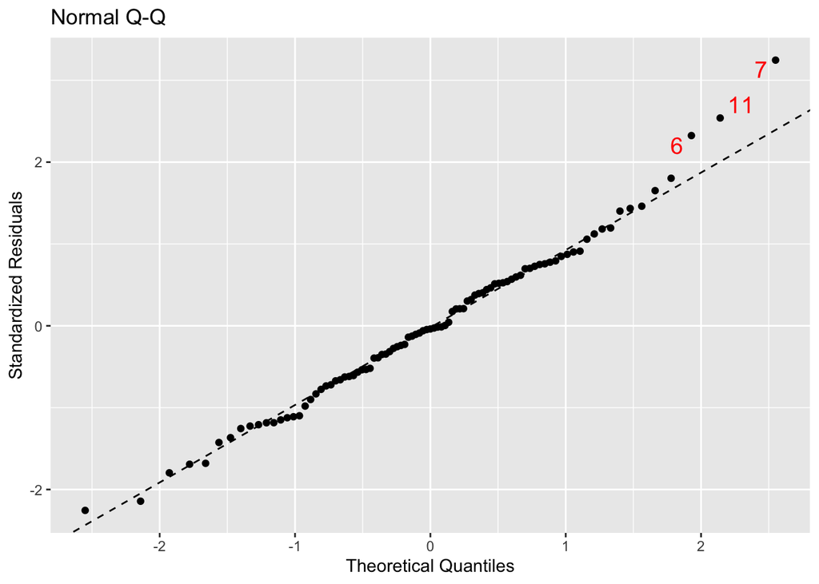

```r
mplot(model2, which=2)
```

7. Interpret the overall F test associated with Model 2. Be sure to include the hypotheses, test statistic, p-value, and a conclusion in the context of the problem.

```r
summary(model2)
```

```
##
## Call:
## lm(formula = bsal ~ senior + educ + exper + age, data = bankSalary)
##
## Residuals:
##      Min       1Q   Median       3Q      Max
## -1308.38  -378.67   -22.45   364.97  1873.29
##
## Coefficients:
##              Estimate Std. Error t value Pr(>|t|)
## (Intercept) 5879.5837   765.3756   7.682 2.06e-11 ***
## senior       -22.4400     6.2469  -3.592  0.00054 ***
## educ         130.1487    28.3551   4.590 1.47e-05 ***
## exper          2.7983     1.1586   2.415  0.01779 *
## age           -1.1022     0.7777  -1.417  0.15992
## ---
## Signif. codes:  0 '***' 0.001 '**' 0.01 '*' 0.05 '.' 0.1 ' ' 1
##
## Residual standard error: 599.4 on 88 degrees of freedom
## Multiple R-squared:  0.3176, Adjusted R-squared:  0.2866
## F-statistic: 10.24 on 4 and 88 DF,  p-value: 7.474e-07
```

For the overall F test, the null hypothesis is that the model is not useful. The alternate hypothesis is that the model is useful. The F statistic is 10.24 which gives a p-value that approaches 0. I must reject the null hypothesis, therefore, and conclude that the model is useful. In the context of this problem, that means that at least one of the coefficients must not equal 0. So at least one of senior, educ, exper, or age must significantly affect starting salary.

8. You should have noticed that the term for age was not statistically significant in Model 2. What does this imply about age and about future modeling steps?

This implies that the age term might not be necessary in future models, and removing it could improve the model.

1. Interpret the slope associated with educ in Model 2.

The slope for educ is 130.15, meaning that one extra year of education should result in an increase of starting salary of $130.15, if all else remains equal.

10. Interpret the y-intercept in Model 2.

The y-intercept of 5879.58 means that an employee with 0 months since being hired, 0 years of education, 0 months of experience, and who is 0 years old should have a starting salary of $5879.58. This company is probably not hiring newborn babies, so the intercept is not useful in this model.

11. Interpret $R^2$ for Model 2.

$R^2$ is 0.3176, which means that 31.76% of variation in staring salary can be explained by the four explanatory variables, senior, educ, exper, and age.

12. Interpret the residual standard error associated with Model 2.

The residual standard error has a value of 599.4 is the standard deviation of the residuals. In this context, it means that the model has an average error of 599.4. A given observation should have a residual of 599.4, meaning that, on average, the model is off by $599.40.

## Uploads

Please upload your .html and .Rmd files in Canvas. Name the files using LastnameFirstinitial_HW1.fileextension.